# Cell composition

各例里各类细胞占多少。占比是相对数。主模型在 scCODA；这里 Wilcoxon 和 miloR 为补充。

样本级细胞占比（描述 + Wilcoxon 敏感性分析），导出给 `07_2_sccoda.ipynb` 做 scCODA / tascCODA，再用 miloR 做邻域差异丰度。主结论看成分模型；Wilcoxon 和 Milo 是补充。`group` 以 **CTRL** 为对照。

先跑本脚本，再在 conda `stroke_bm` 里跑 `codes/07_2_sccoda.ipynb`。

```r
pacman::p_load(
  Seurat, tidyverse, qs2, cowplot, SingleCellExperiment
)
knitr::opts_knit$set(root.dir = "/home/han/Desktop/guoqiang/stroke_bm/stroke_bm_Rproj")
setwd("/home/han/Desktop/guoqiang/stroke_bm/stroke_bm_Rproj")
source("codes/plot_colors.R")
```

```r
res_path <- "results/composition"
tab_path <- "data/rdata/composition"
if (dir.exists(res_path)) {
  old_res <- list.files(res_path, full.names = TRUE)
  old_res <- old_res[!grepl("^03_s?ccoda|^03_tasc", basename(old_res))]
  if (length(old_res) > 0) unlink(old_res, recursive = TRUE)
} else {
  dir.create(res_path, recursive = TRUE)
}
if (!dir.exists(tab_path)) dir.create(tab_path, recursive = TRUE)
```

```r
n_dims <- 20
```

```r
seurat_object <- qs_read("data/rdata/seurat_object_final.qs2", nthreads = 10)
stopifnot(all(c("sample", "group", "annot_main", "annot_sub") %in%
  colnames(seurat_object[[]])))
seurat_object$group <- factor(seurat_object$group, levels = c("CTRL", "ACI"))
cell_meta <- FetchData(
  seurat_object,
  vars = c("sample", "group", "annot_main", "annot_sub")
) |>
  rownames_to_column("barcode")
sample_meta <- cell_meta |>
  distinct(sample, group) |>
  arrange(group, sample)
print(table(cell_meta$group, cell_meta$sample))
```

```
       ACI-1 ACI-2 ACI-3 ACI-4 ACI-5 CTRL-1 CTRL-2 CTRL-3 CTRL-4 CTRL-5 CTRL-6
  CTRL     0     0     0     0     0   1642   4851   3088   5615   1856   5686
  ACI   7204  7246  8998  7217  7787      0      0      0      0      0      0
```

```r
print(table(cell_meta$annot_main, cell_meta$group))
```

```
            CTRL   ACI
  HSPC      1390  1976
  B         3641   664
  Plasma     445   109
  T         6894  3560
  NK         954   793
  Mono/DC   2060  1850
  pDC        363   103
  Pre-Neut  1216 12291
  Neut       885 16783
  Ery       4890   323
```

### 1. Sample proportions

堆叠图和箱线：每个点是一例里该类占全部细胞的百分之几。

每个点是一例里该类占全部细胞的比例。先看中性粒、Pre-Neut 和 HSPC 是否整体上移；组成推断以 07.2 的模型为准。

```r
make_prop <- function(meta, cell_col) {
  totals <- meta |>
    dplyr::count(sample, group, name = "n_total")
  meta |>
    dplyr::count(sample, group, cell = .data[[cell_col]], name = "n") |>
    complete(nesting(sample, group), cell, fill = list(n = 0)) |>
    left_join(totals, by = c("sample", "group")) |>
    mutate(
      prop = n / n_total,
      cell = factor(cell, levels = levels(meta[[cell_col]]))
    )
}

prop_main <- make_prop(cell_meta, "annot_main")
prop_sub <- make_prop(cell_meta, "annot_sub")
write_csv(cell_meta, file.path(tab_path, "cell_meta.csv"))
write_csv(sample_meta, file.path(tab_path, "sample_meta.csv"))
write_csv(prop_main, file.path(tab_path, "prop_main.csv"))
write_csv(prop_sub, file.path(tab_path, "prop_sub.csv"))
```

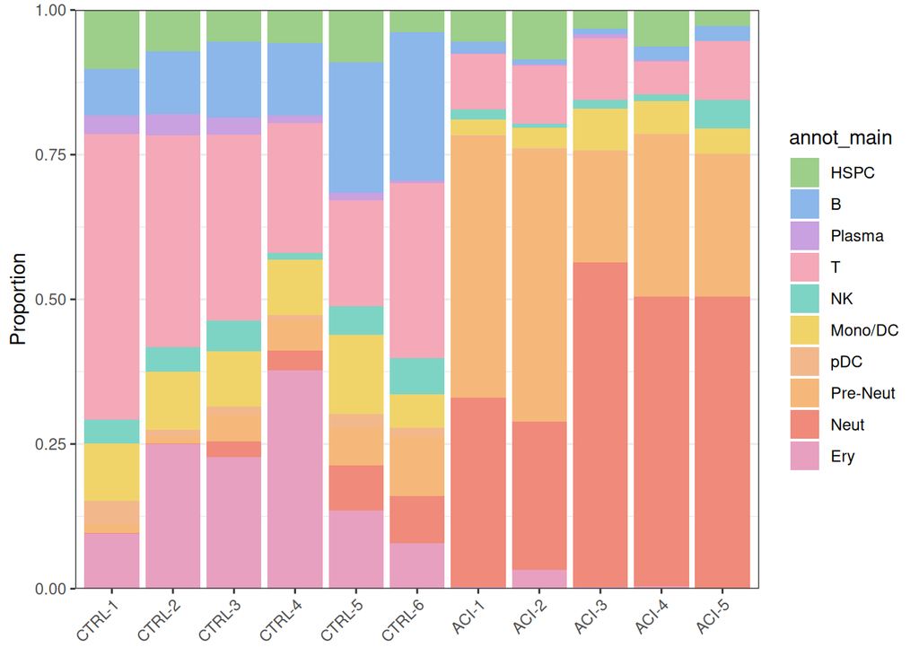

```r
sample_order <- sample_meta$sample
ggplot(prop_main, aes(sample, prop, fill = cell)) +
  geom_col(width = 0.9) +
  scale_x_discrete(limits = sample_order) +
  scale_y_continuous(expand = c(0, 0)) +
  scale_fill_manual(values = annot_main_col) +
  theme_bw() +
  theme(
    axis.text.x = element_text(angle = 45, hjust = 1),
    legend.position = "right"
  ) +
  labs(x = NULL, y = "Proportion", fill = "annot_main")
```

```r
ggsave(
  file.path(res_path, "01_prop_main_bar.pdf"),
  width = 10, height = 5, dpi = 600
)
```

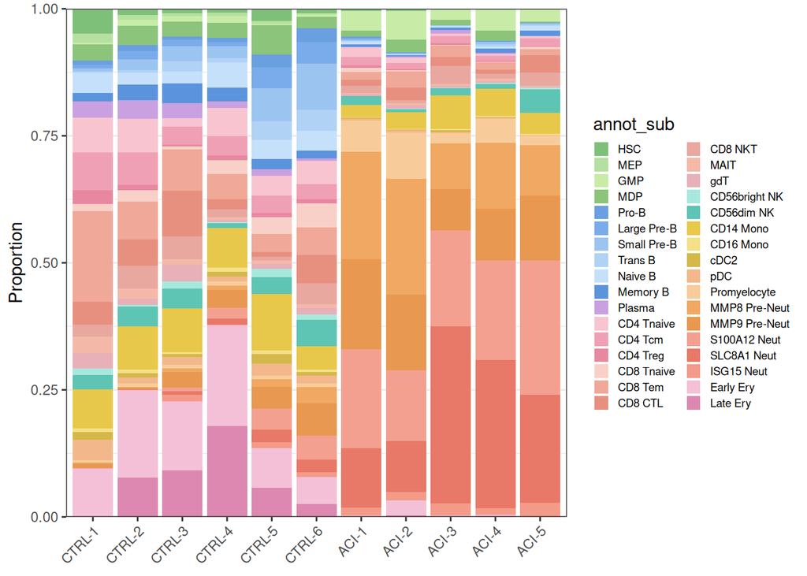

```r
ggplot(prop_sub, aes(sample, prop, fill = cell)) +
  geom_col(width = 0.9) +
  scale_x_discrete(limits = sample_order) +
  scale_y_continuous(expand = c(0, 0)) +
  scale_fill_manual(values = annot_sub_col) +
  theme_bw() +
  theme(
    axis.text.x = element_text(angle = 45, hjust = 1),
    legend.position = "right",
    legend.key.size = unit(0.35, "cm"),
    legend.text = element_text(size = 7)
  ) +
  labs(x = NULL, y = "Proportion", fill = "annot_sub")
```

```r
ggsave(
  file.path(res_path, "01_prop_sub_bar.pdf"),
  width = 12, height = 6, dpi = 600
)
```

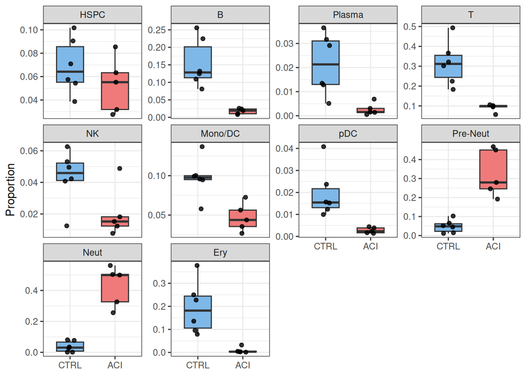

```r
ggplot(prop_main, aes(group, prop, fill = group)) +
  geom_boxplot(outlier.shape = NA, width = 0.6) +
  geom_jitter(width = 0.12, size = 1.5, alpha = 0.8) +
  scale_fill_manual(values = group_col) +
  facet_wrap(~cell, scales = "free_y") +
  theme_bw() +
  theme(legend.position = "none") +
  labs(x = NULL, y = "Proportion")
```

```r
ggsave(
  file.path(res_path, "01_prop_main_box.pdf"),
  width = 12, height = 8, dpi = 600
)
```

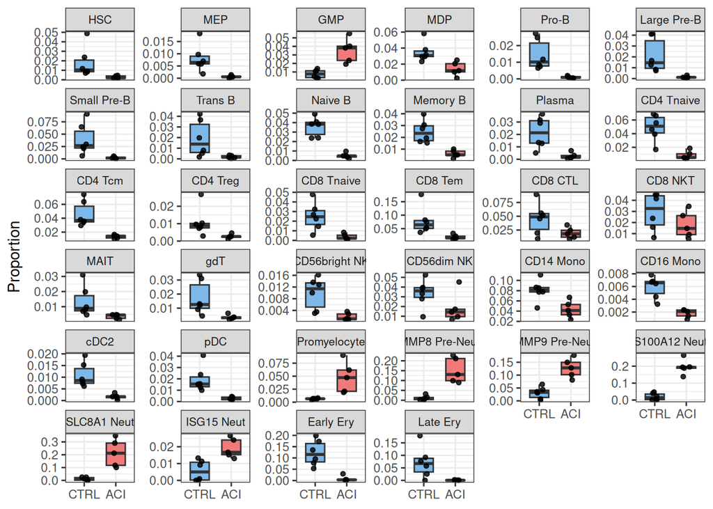

```r
ggplot(prop_sub, aes(group, prop, fill = group)) +
  geom_boxplot(outlier.shape = NA, width = 0.6) +
  geom_jitter(width = 0.12, size = 1.2, alpha = 0.8) +
  scale_fill_manual(values = group_col) +
  facet_wrap(~cell, scales = "free_y") +
  theme_bw() +
  theme(legend.position = "none", strip.text = element_text(size = 8)) +
  labs(x = NULL, y = "Proportion")
```

```r
ggsave(
  file.path(res_path, "01_prop_sub_box.pdf"),
  width = 16, height = 12, dpi = 600
)
```

### 2. Wilcoxon (sensitivity)

用 6 vs 5 个样本做 Wilcoxon，只是敏感性分析。主模型在 07.2。

6 vs 5 的 Wilcoxon 不考虑「占比加总为 100%」，只作对照。主结果看 07.2。

```r
wilcox_props <- function(prop_df) {
  prop_df |>
    group_by(cell) |>
    group_modify(function(d, key) {
      ctrl <- d$prop[d$group == "CTRL"]
      aci <- d$prop[d$group == "ACI"]
      tibble(
        n_ctrl = length(ctrl),
        n_aci = length(aci),
        median_ctrl = median(ctrl),
        median_aci = median(aci),
        delta_aci_minus_ctrl = median_aci - median_ctrl,
        p = wilcox.test(aci, ctrl, exact = FALSE)$p.value
      )
    }) |>
    ungroup() |>
    mutate(p_adj = p.adjust(p, method = "BH")) |>
    arrange(p)
}

wilcox_main <- wilcox_props(prop_main)
wilcox_sub <- wilcox_props(prop_sub)
write_csv(wilcox_main, file.path(res_path, "02_wilcox_main.csv"))
write_csv(wilcox_sub, file.path(res_path, "02_wilcox_sub.csv"))
wilcox_main
```

```
# A tibble: 10 × 8
   cell  n_ctrl n_aci median_ctrl median_aci delta_aci_minus_ctrl       p  p_adj
   <fct>  <int> <int>       <dbl>      <dbl>                <dbl>   <dbl>  <dbl>
 1 B          6     5      0.128     0.0193              -0.109   0.00811 0.0135
 2 T          6     5      0.312     0.0996              -0.212   0.00811 0.0135
 3 pDC        6     5      0.0154    0.00236             -0.0131  0.00811 0.0135
 4 Pre-…      6     5      0.0485    0.279                0.231   0.00811 0.0135
 5 Neut       6     5      0.0305    0.500                0.469   0.00811 0.0135
 6 Ery        6     5      0.182     0.00319             -0.178   0.00811 0.0135
 7 Plas…      6     5      0.0213    0.00153             -0.0198  0.0137  0.0171
 8 Mono…      6     5      0.0976    0.0438              -0.0538  0.0137  0.0171
 9 NK         6     5      0.0459    0.0152              -0.0307  0.0828  0.0920
10 HSPC       6     5      0.0642    0.0552              -0.00897 0.315   0.315
```

```r
wilcox_sub
```

```
# A tibble: 34 × 8
   cell  n_ctrl n_aci median_ctrl median_aci delta_aci_minus_ctrl       p  p_adj
   <fct>  <int> <int>       <dbl>      <dbl>                <dbl>   <dbl>  <dbl>
 1 HSC        6     5     0.0104    0.00208              -0.00828 0.00811 0.0145
 2 MEP        6     5     0.00644   0.000556             -0.00588 0.00811 0.0145
 3 GMP        6     5     0.00772   0.0382                0.0305  0.00811 0.0145
 4 Pro-B      6     5     0.0101    0.000831             -0.00931 0.00811 0.0145
 5 Larg…      6     5     0.0146    0.00116              -0.0134  0.00811 0.0145
 6 Smal…      6     5     0.0268    0.00167              -0.0252  0.00811 0.0145
 7 Naiv…      6     5     0.0384    0.00485              -0.0335  0.00811 0.0145
 8 Memo…      6     5     0.0234    0.00511              -0.0183  0.00811 0.0145
 9 CD4 …      6     5     0.0368    0.0142               -0.0226  0.00811 0.0145
10 CD8 …      6     5     0.0641    0.0151               -0.0490  0.00811 0.0145
# ℹ 24 more rows
```

### 3. Export note

把计数表交给下一篇 scCODA。

把每例各类细胞计数交给 scCODA / tascCODA。

### 4. miloR

不按我们起的名字，而按转录组邻居圈一块细胞再比丰度。方向应和占比大致同向，细节可以不完全一样。

邻域丰度：正 logFC（红）= ACI 更富集。SpatialFDR < 0.1 常当作「这片邻居可信」。应和占比图方向大致一致。

在 Harmony 邻域上检验 ACI vs CTRL。不依赖离散 cluster；邻域再用 `annot_main` / `annot_sub` 注释。

```r
pacman::p_load(miloR)
DefaultAssay(seurat_object) <- "RNA"
sce <- as.SingleCellExperiment(seurat_object, assay = "RNA")
reducedDim(sce, "HARMONY") <-
  Embeddings(seurat_object, "harmony")[, 1:n_dims, drop = FALSE]
reducedDim(sce, "UMAP") <- Embeddings(seurat_object, "umap")
colData(sce)$sample <- as.character(colData(sce)$sample)
colData(sce)$group <- factor(colData(sce)$group, levels = c("CTRL", "ACI"))

milo <- Milo(sce)
milo <- buildGraph(milo, k = 20, d = n_dims, reduced.dim = "HARMONY")
milo <- makeNhoods(
  milo, prop = 0.05, k = 20, d = n_dims,
  refined = TRUE, reduced_dims = "HARMONY"
)
milo <- countCells(
  milo,
  meta.data = data.frame(colData(milo)),
  samples = "sample"
)
milo <- calcNhoodDistance(milo, d = n_dims, reduced.dim = "HARMONY")

design_df <- data.frame(colData(milo))[, c("sample", "group")] |>
  distinct()
rownames(design_df) <- design_df$sample
design_df <- design_df[colnames(nhoodCounts(milo)), , drop = FALSE]
design_df$group <- factor(design_df$group, levels = c("CTRL", "ACI"))

da_results <- testNhoods(
  milo,
  design = ~group,
  design.df = design_df,
  reduced.dim = "HARMONY"
)
da_results <- annotateNhoods(milo, da_results, coldata_col = "annot_main")
da_results <- annotateNhoods(milo, da_results, coldata_col = "annot_sub")
milo <- buildNhoodGraph(milo)
write_csv(da_results, file.path(res_path, "04_milo_da.csv"))
table(sign(da_results$logFC), da_results$SpatialFDR < 0.1)
```

```
     FALSE TRUE
  -1   468  697
  1    144 1339
```

```r
summary(da_results$SpatialFDR)
```

```
     Min.   1st Qu.    Median      Mean   3rd Qu.      Max.
0.0000103 0.0002320 0.0031989 0.1071384 0.0712841 0.9986929
```

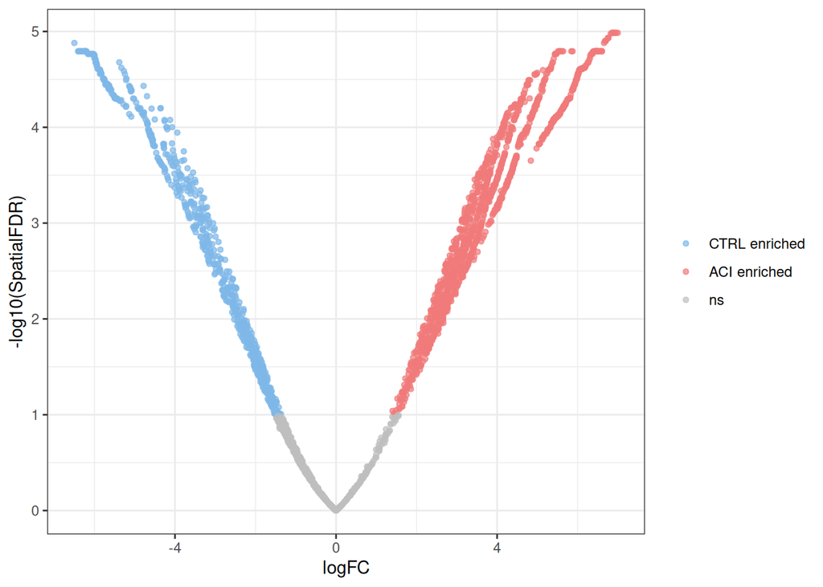

```r
da_results <- da_results |>
  mutate(
    da_dir = case_when(
      SpatialFDR >= 0.1 | is.na(SpatialFDR) ~ "ns",
      logFC > 0 ~ "ACI",
      TRUE ~ "CTRL"
    ),
    da_dir = factor(da_dir, levels = c("CTRL", "ACI", "ns"))
  )
ggplot(da_results, aes(logFC, -log10(SpatialFDR))) +
  geom_point(aes(color = da_dir), alpha = 0.7, size = 1.2) +
  scale_color_manual(
    values = c(group_col, ns = "grey75"),
    breaks = c("CTRL", "ACI", "ns"),
    labels = c("CTRL enriched", "ACI enriched", "ns")
  ) +
  theme_bw() +
  labs(color = NULL)
```

```r
ggsave(
  file.path(res_path, "04_milo_volcano.pdf"),
  width = 7, height = 5, dpi = 600
)
```

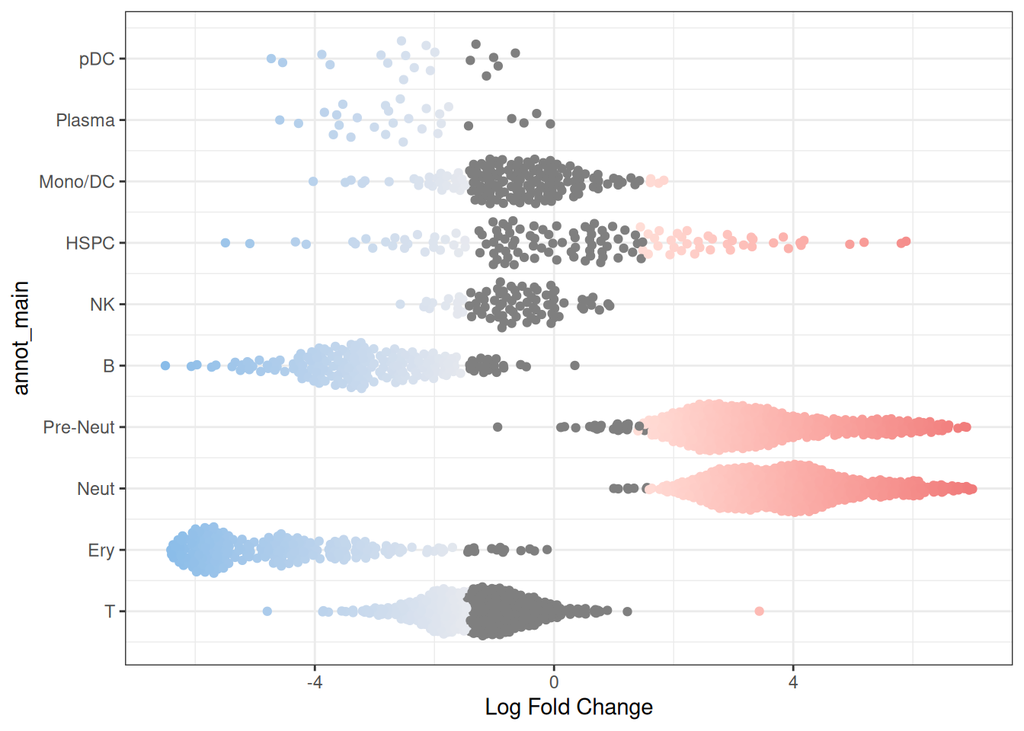

```r
plotDAbeeswarm(da_results, group.by = "annot_main") +
  scale_color_gradient2(
    low = milo_div_col["low"],
    mid = milo_div_col["mid"],
    high = milo_div_col["high"]
  ) +
  theme_bw()
```

```r
ggsave(
  file.path(res_path, "04_milo_beeswarm_main.pdf"),
  width = 8, height = 6, dpi = 600
)
```

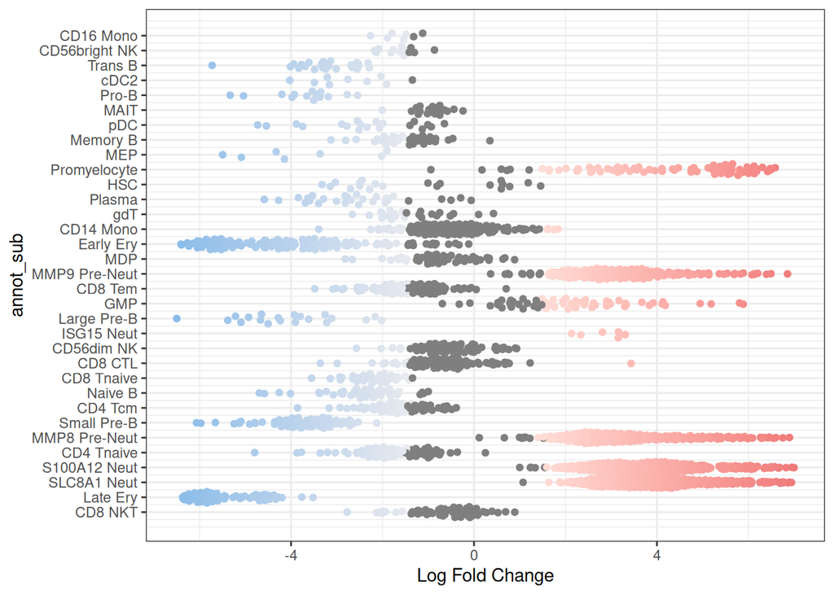

```r
plotDAbeeswarm(da_results, group.by = "annot_sub") +
  scale_color_gradient2(
    low = milo_div_col["low"],
    mid = milo_div_col["mid"],
    high = milo_div_col["high"]
  ) +
  theme_bw()
```

```r
ggsave(
  file.path(res_path, "04_milo_beeswarm_sub.pdf"),
  width = 8, height = 10, dpi = 600
)
```

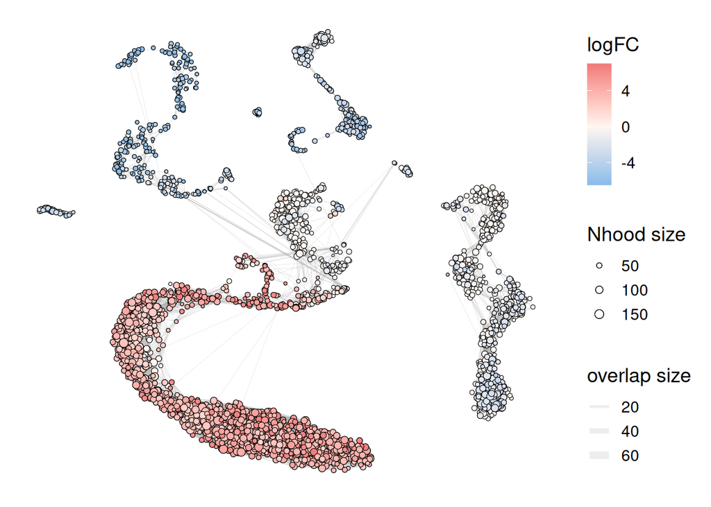

```r
plotNhoodGraphDA(
  milo, as.data.frame(da_results), alpha = 0.1, layout = "UMAP"
) +
  scale_fill_gradient2(
    low = milo_div_col["low"],
    mid = milo_div_col["mid"],
    high = milo_div_col["high"],
    name = "logFC"
  )
```

```r
ggsave(
  file.path(res_path, "04_milo_graph.pdf"),
  width = 8, height = 8, dpi = 600
)
```

```r
qs_save(milo, file.path(tab_path, "milo.qs2"), nthreads = 10)
```